# EDA

zamora tello, Romero Cardenas, Laymito Enriquez, Lopez Soto, Alata Diego

10/9/2021

#### GRUPO 2

# DESCRIPCION DEL CASO DE ESTUDIO

El Perú es un país con una tradición milenaria y un promisorio futuro que no pierde de vista sus raíces y donde el buen comer destaca entre sus habitantes como uno de los signos más distintivos de su identidad.  
El pueblo peruano es famoso por su paladar exigente, el cual proviene de épocas inmemorables. Las técnicas precolombinas permitieron la preparación de sopas, guisos y pescados crudos. El procesamiento de la comida era parte común de la vida diaria, al contar con conocimientos para salar carne, deshidratar y cocer en hornos de tierra natural. Con la colonización española, unida a la migración africana, china, italiana y japonesa, la cocina peruana acogió diferentes formas de ver el mundo y nuevas técnicas de preparación. Destaca la influencia de España y de China, que originó gastronomías con denominación propia: comida criolla y chifa, respectivamente. La riqueza de la cocina peruana se sustenta en el mestizaje de sus culturas; así como en la existencia de una de las mayores biodiversidades de la Tierra, lo que ha producido el nacimiento y evolución de gastronomías únicas. Lima, ha sido declarada capital gastronómica de Latinoamérica gracias a la amplitud y exquisitez de platillos aprobados de forma contundente por los más prestigiosos chefs y restaurantes, los cuales son impulsores de innovaciones y vanguardias a través de la alta cocina.

# DESCRIPCION DE LAS VARIABLES

```r
datavariable <- read_excel("variables.xlsx")
knitr::kable(datavariable)
```

| Variable | Descripción |
| --- | --- |
| Identificación | Id del restaurante |
| Nombre | Nombre del restaurante |
| x, y | Información geoespacial y ubicación exacta del restaurante. |
| Distrito | Distrito donde se encuentra el restaurante |
| Dirección | Distrito donde se encuentra el restaurante |
| N_reviews | Número de reseñas de restaurantes en todo el tiempo |
| Min_Price | Precio mínimo en el menú del restaurante |
| Max_Price | Precio máximo en el menú del restaurante |
| Enfado | Probabilidad de revisión de que mostrará ira |
| Anticipación | Probabilidad de revisión de que mostrará emoción de anticipación |
| Disgusto | Probabilidad de revisión de que mostrará una emoción de disgusto |
| Temor | Probabilidad de revisión de que mostrará miedo |
| Alegría | Probabilidad de revisión que mostrará alegría |
| Tristeza | Probabilidad de revisión que mostrará tristeza |
| Sorpresa | Probabilidad de revisión de que mostrará emoción de sorpresa |
| Confianza | Probabilidad de revision de que mostrará de agradecimiento |
| Positivo | Probabilidad de revisión de que mostrará un sentimiento positivo |
| Negativo | Probabilidad de revisión de que mostrará un sentimiento negativo |
| Stars_1 | Probabilidad de revisión de que obtendrá 1 estrella |
| Stars_2 | Probabilidad de revisión de que obtendrá 2 estrellas |
| Stars_3 | Probabilidad de revisión de que obtendrá 3 estrellas |
| Stars_4 | Probabilidad de revisión de que obtendrá 4 estrellas |
| Stars_5 | Probabilidad de revisión de que obtendrá 5 estrellas |

El cuadro muestra los campos al iniciar el proceso del conjunto de datos; a continuación, se mostrará finalmente las variables a trabajar:

```r
datavariable1 <- read_excel("variables1.xlsx")
knitr::kable(datavariable1)
```

| Variable | Descripción |
| --- | --- |
| Enfado | Probabilidad de revisión de que mostrará ira |
| Anticipación | Probabilidad de revisión de que mostrará emoción de anticipación |
| Disgusto | Probabilidad de revisión de que mostrará una emoción de disgusto |
| Temor | Probabilidad de revisión de que mostrará miedo |
| Alegría | Probabilidad de revisión que mostrará alegría |
| Tristeza | Probabilidad de revisión que mostrará tristeza |
| Sorpresa | Probabilidad de revisión de que mostrará emoción de sorpresa |
| Confianza | Probabilidad de revision de que mostrará de agradecimiento |
| Positivo | Probabilidad de revisión de que mostrará un sentimiento positivo |
| Negativo | Probabilidad de revisión de que mostrará un sentimiento negativo |
| Stars_1 | Probabilidad de revisión de que obtendrá 1 estrella |
| Stars_2 | Probabilidad de revisión de que obtendrá 2 estrellas |
| Stars_3 | Probabilidad de revisión de que obtendrá 3 estrellas |
| Stars_4 | Probabilidad de revisión de que obtendrá 4 estrellas |
| Stars_5 | Probabilidad de revisión de que obtendrá 5 estrellas |

# ANALISIS EXPLORATORIO DE DATOS(EDA)

```r
(data1 <- read_excel("restaurantes3.xlsx"))
```

```
## # A tibble: 1,217 x 24
##    id     name    x         y district direction   n_reviews min_price max_price
##    <chr>  <chr>   <chr> <dbl> <chr>    <chr>       <chr>     <chr>     <chr>
##  1 R1474~ .20 Ca~ -12.~ -77.1 PUEBLO ~ Av. Brasil~ 45        48        <NA>
##  2 R1096~ 14 de ~ -12.~ -77.1 JESUS M~ Mello Fran~ 25        11        <NA>
##  3 R26571 3 Cont~ -12.~ -77.0 LIMA     Jirón Chot~ 41        831       <NA>
##  4 R1526~ 401 RE~ -12.~ -77.1 LOS OLI~ Av. Univer~ 45        2         <NA>
##  5 R1029~ 50/50 ~ -12.~ -77.0 LA VICT~ Santa Cata~ <NA>      42        66
##  6 R1433~ A la C~ -12.~ -77.0 SAN BOR~ Av. Angamo~ 50        5         <NA>
##  7 R44479 Aci gu~ -12.~ -77.0 SAN BOR~ Av San Lui~ 36        110       <NA>
##  8 R1215~ Agallas -12.~ -77.0 LA VICT~ Av. Manco ~ 45        8         <NA>
##  9 R83764 Agenci~ -12.~ -77.0 LIMA     Av. Arenal~ 36        11        <NA>
## 10 R69055 Aguaym~ -12.~ -77.1 JESUS M~ Av Horacio~ 39        166       <NA>
## # ... with 1,207 more rows, and 15 more variables: enfado <dbl>,
## #   anticipacion <dbl>, disgusto <dbl>, temor <dbl>, alegria <dbl>,
## #   tristesa <dbl>, sorpresa <dbl>, confianza <dbl>, negative <dbl>,
## #   positive <dbl>, stars_1 <dbl>, stars_2 <dbl>, stars_3 <dbl>, stars_4 <dbl>,
## #   stars_5 <dbl>
```

```r
glimpse(data1)
```

```
## Rows: 1,217
## Columns: 24
## $ id           <chr> "R147468", "R109689", "R26571", "R152623", "R102925", "R1~
## $ name         <chr> ".20 Café & Burger", "14 de Garzon", "3 Continentes Resta~
## $ x            <chr> "-12.0784876", "-12.07462", "-12.050185", "-12.0091436", ~
## $ y            <dbl> -77.05684, -77.05217, -77.04151, -77.08129, -77.01570, -7~
## $ district     <chr> "PUEBLO LIBRE", "JESUS MARIA", "LIMA", "LOS OLIVOS", "LA ~
## $ direction    <chr> "Av. Brasil 2002", "Mello Franco 171", "Jirón Chota 774",~
## $ n_reviews    <chr> "45", "25", "41", "45", NA, "50", "36", "45", "36", "39",~
## $ min_price    <chr> "48", "11", "831", "2", "42", "5", "110", "8", "11", "166~
## $ max_price    <chr> NA, NA, NA, NA, "66", NA, NA, NA, NA, NA, "233", NA, NA, ~
## $ enfado       <dbl> 0.09090909, 0.00000000, 0.00000000, 0.07692308, 0.0000000~
## $ anticipacion <dbl> 0.09090909, 0.08333333, 0.40000000, 0.15384615, 0.1250000~
## $ disgusto     <dbl> 0.09090909, 0.08333333, 0.00000000, 0.07692308, 0.0000000~
## $ temor        <dbl> 0.09090909, 0.16666667, 0.20000000, 0.00000000, 0.2500000~
## $ alegria      <dbl> 0.2727273, 0.3333333, 0.0000000, 0.3076923, 0.1250000, 0.~
## $ tristesa     <dbl> 0.09090909, 0.00000000, 0.20000000, 0.07692308, 0.1250000~
## $ sorpresa     <dbl> 0.09090909, 0.08333333, 0.00000000, 0.00000000, 0.1250000~
## $ confianza    <dbl> 0.1818182, 0.2500000, 0.2000000, 0.3076923, 0.2500000, 0.~
## $ negative     <dbl> 0.20000000, 0.16666667, 0.40000000, 0.27272727, 0.6666666~
## $ positive     <dbl> 0.8000000, 0.8333333, 0.6000000, 0.7272727, 0.3333333, 1.~
## $ stars_1      <dbl> 5.286488e-03, 3.294896e-04, 5.125770e-01, 1.537415e-02, 6~
## $ stars_2      <dbl> 9.952374e-03, 3.563266e-04, 2.138119e-01, 2.852804e-02, 1~
## $ stars_3      <dbl> 0.0896082093, 0.0178754787, 0.1818742475, 0.2428166007, 0~
## $ stars_4      <dbl> 0.249553344, 0.259555481, 0.042752922, 0.481257133, 0.616~
## $ stars_5      <dbl> 0.645599586, 0.721883224, 0.048983979, 0.232024077, 0.249~
```

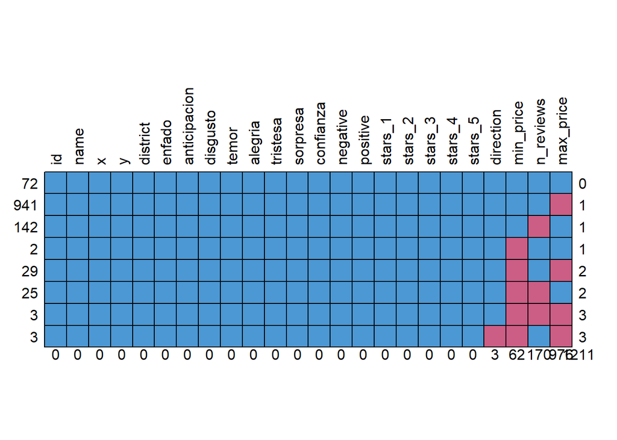

```
##     id name x y district enfado anticipacion disgusto temor alegria tristesa
## 72   1    1 1 1        1      1            1        1     1       1        1
## 941  1    1 1 1        1      1            1        1     1       1        1
## 142  1    1 1 1        1      1            1        1     1       1        1
## 2    1    1 1 1        1      1            1        1     1       1        1
## 29   1    1 1 1        1      1            1        1     1       1        1
## 25   1    1 1 1        1      1            1        1     1       1        1
## 3    1    1 1 1        1      1            1        1     1       1        1
## 3    1    1 1 1        1      1            1        1     1       1        1
##      0    0 0 0        0      0            0        0     0       0        0
##     sorpresa confianza negative positive stars_1 stars_2 stars_3 stars_4
## 72         1         1        1        1       1       1       1       1
## 941        1         1        1        1       1       1       1       1
## 142        1         1        1        1       1       1       1       1
## 2          1         1        1        1       1       1       1       1
## 29         1         1        1        1       1       1       1       1
## 25         1         1        1        1       1       1       1       1
## 3          1         1        1        1       1       1       1       1
## 3          1         1        1        1       1       1       1       1
##            0         0        0        0       0       0       0       0
##     stars_5 direction min_price n_reviews max_price
## 72        1         1         1         1         1    0
## 941       1         1         1         1         0    1
## 142       1         1         1         0         1    1
## 2         1         1         0         1         1    1
## 29        1         1         0         1         0    2
## 25        1         1         0         0         1    2
## 3         1         1         0         0         0    3
## 3         1         0         0         1         0    3
##           0         3        62       170       976 1211
```

```r
# distribucion de NA en las variables  y  observaciones
mice::md.pattern(data1,rotate.names= TRUE )
```

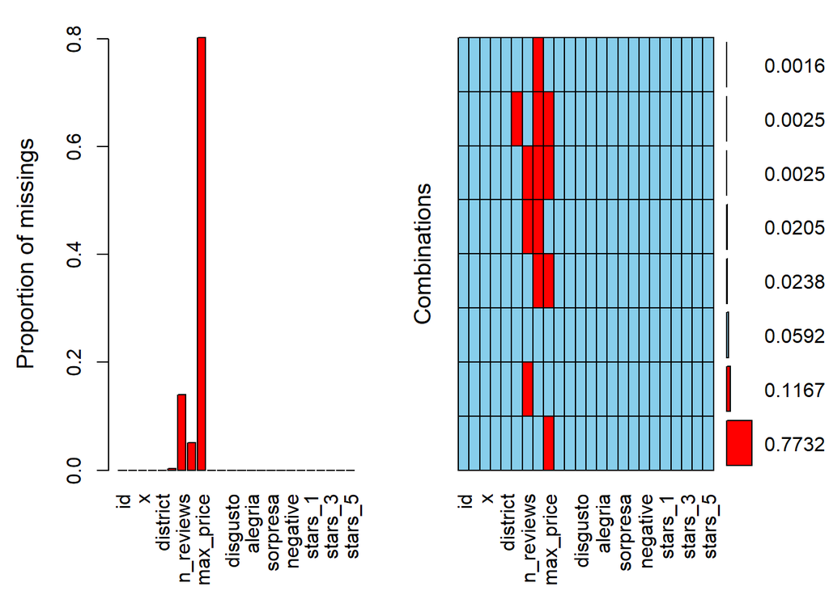

```r
VIM::aggr(data1 , numbers = T , SortVar = T)
```

# missing values

**CANTIDAD DE NA**

```r
sum(is.na( data1$n_reviews) )
```

```
## [1] 170
```

```r
sum(is.na( data1$min_price) )
```

```
## [1] 62
```

```r
sum(is.na( data1$max_price) )
```

```
## [1] 976
```

```r
#calculo de mediana para n_reviews
data1 %>%
  dplyr::summarise(n_reviews=median(n_reviews,na.rm = T ))
```

```
## # A tibble: 1 x 1
##   n_reviews
##   <chr>
## 1 41
```

```r
##calculo de mediana para min_price
data1 %>%
  dplyr::summarise(min_price=median(min_price,na.rm = T ))
```

```
## # A tibble: 1 x 1
##   min_price
##   <chr>
## 1 325
```

**reemplazando los NA por mediana**

```r
data2<- data1 %>%
 mutate(n_reviews= ifelse(is.na(n_reviews) , 41,n_reviews),
        min_price= ifelse(is.na(min_price) , 325,min_price)
)
(view(data2))
```

```
## # A tibble: 1,217 x 24
##    id     name    x         y district direction   n_reviews min_price max_price
##    <chr>  <chr>   <chr> <dbl> <chr>    <chr>       <chr>     <chr>     <chr>
##  1 R1474~ .20 Ca~ -12.~ -77.1 PUEBLO ~ Av. Brasil~ 45        48        <NA>
##  2 R1096~ 14 de ~ -12.~ -77.1 JESUS M~ Mello Fran~ 25        11        <NA>
##  3 R26571 3 Cont~ -12.~ -77.0 LIMA     Jirón Chot~ 41        831       <NA>
##  4 R1526~ 401 RE~ -12.~ -77.1 LOS OLI~ Av. Univer~ 45        2         <NA>
##  5 R1029~ 50/50 ~ -12.~ -77.0 LA VICT~ Santa Cata~ 41        42        66
##  6 R1433~ A la C~ -12.~ -77.0 SAN BOR~ Av. Angamo~ 50        5         <NA>
##  7 R44479 Aci gu~ -12.~ -77.0 SAN BOR~ Av San Lui~ 36        110       <NA>
##  8 R1215~ Agallas -12.~ -77.0 LA VICT~ Av. Manco ~ 45        8         <NA>
##  9 R83764 Agenci~ -12.~ -77.0 LIMA     Av. Arenal~ 36        11        <NA>
## 10 R69055 Aguaym~ -12.~ -77.1 JESUS M~ Av Horacio~ 39        166       <NA>
## # ... with 1,207 more rows, and 15 more variables: enfado <dbl>,
## #   anticipacion <dbl>, disgusto <dbl>, temor <dbl>, alegria <dbl>,
## #   tristesa <dbl>, sorpresa <dbl>, confianza <dbl>, negative <dbl>,
## #   positive <dbl>, stars_1 <dbl>, stars_2 <dbl>, stars_3 <dbl>, stars_4 <dbl>,
## #   stars_5 <dbl>
```

# Multicolineidad

```r
data3 <- data2 %>%
  dplyr::select(-x,-y,-district,-direction ,-max_price)
dataordenada<- data3 %>%
  dplyr::select(-min_price,-n_reviews)
```

```r
data4 <- data3 %>%
  dplyr::select(-name,-id,-min_price,-n_reviews)
```

**GRAFICO DE CORRELACION**

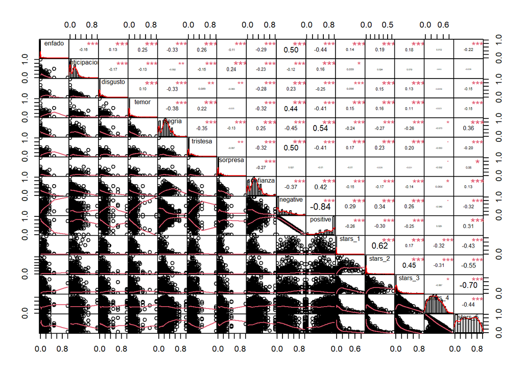

```r
chart.Correlation(data4, histogram = TRUE, method = "pearson")
```

# Outliers

**DIAGRAMA DE CAJAS**

```r
(data5 <- dplyr::filter(dataordenada,name =="KFC"  | name == "Pizza Hut"| name == "Bembos"|name == "El Chinito" | name == "El Chinito"|name == "Embarcadero 41" |name == "McDonald's" | name == "Norky's"|name == "Papa John's"|name == "Popeyes"
|name == "Roky's"| name == "Roky's"|name == "Rustica"|name == "Starbucks"))
```

```
## # A tibble: 67 x 17
##    id     name     enfado anticipacion disgusto  temor alegria tristesa sorpresa
##    <chr>  <chr>     <dbl>        <dbl>    <dbl>  <dbl>   <dbl>    <dbl>    <dbl>
##  1 R1312~ Bembos   0             0.111   0.222  0        0.111   0.111    0.111
##  2 R53652 Bembos   0.2           0.1     0      0.2      0.1     0.2      0
##  3 R1119~ Bembos   0             0.4     0      0.2      0.2     0        0
##  4 R1300~ Bembos   0             0.167   0.0556 0        0.389   0.0556   0
##  5 R29802 Bembos   0             0.143   0.0714 0.143    0.214   0        0.143
##  6 R7805  Bembos   0.0323        0.161   0      0        0.290   0.161    0.0645
##  7 R58353 Bembos   0             0       0      0        0.5     0        0
##  8 R74206 El Chin~ 0             0.2     0      0        0.4     0        0
##  9 R4303  El Chin~ 0             0       0      0        0.5     0        0
## 10 R95856 Embarca~ 0.0556        0.278   0.0556 0.0556   0.167   0.111    0.0556
## # ... with 57 more rows, and 8 more variables: confianza <dbl>, negative <dbl>,
## #   positive <dbl>, stars_1 <dbl>, stars_2 <dbl>, stars_3 <dbl>, stars_4 <dbl>,
## #   stars_5 <dbl>
```

**analisis de la variable confianza**

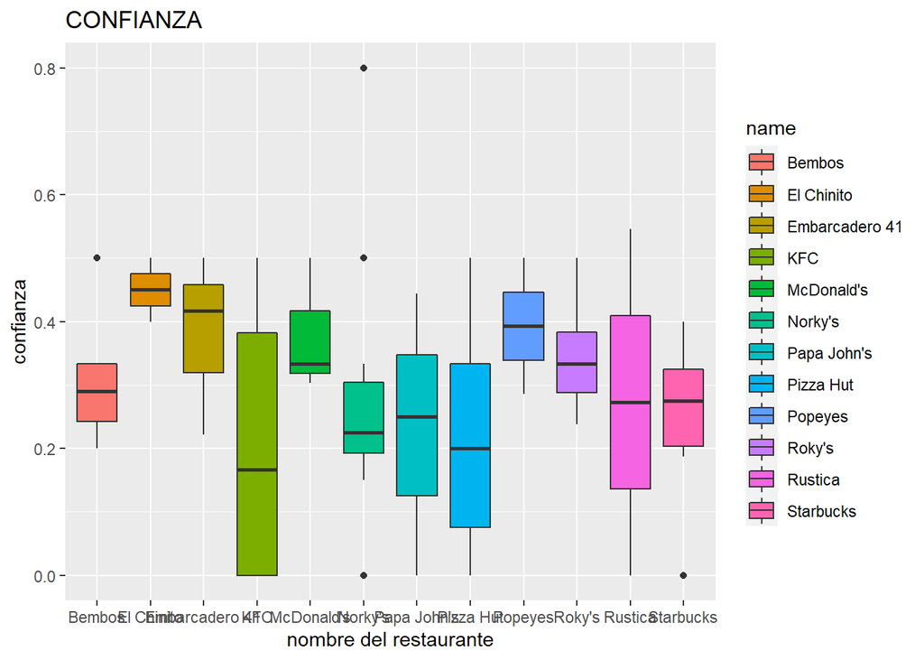

```r
(data6 <- data5 %>%
    group_by(name,confianza ) %>%
    ggplot(mapping = aes(x = name, y = confianza, fill = name))+
    geom_boxplot()+
    labs (title = "CONFIANZA",
          x = "nombre del restaurante",
          y = "confianza"
    ))
```

**analisis de la variable enfado**

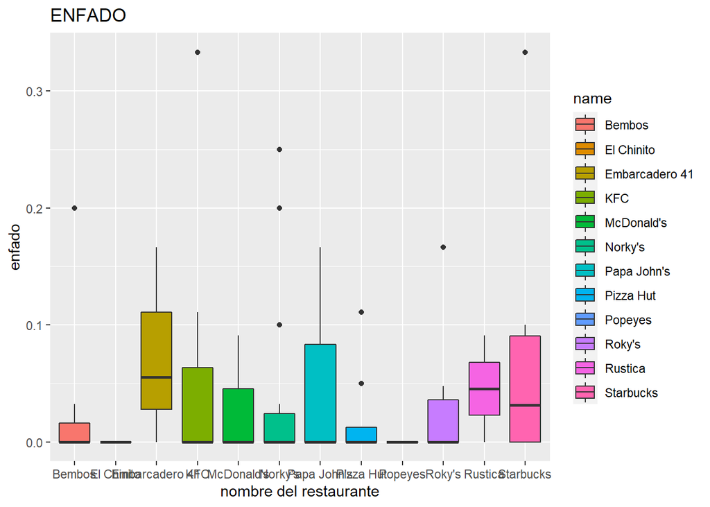

```r
(data7<- data5 %>%
    group_by(name,enfado ) %>%
    ggplot(mapping = aes(x = name, y = enfado, fill = name))+
    geom_boxplot()+
    labs (title = "ENFADO",
          x = "nombre del restaurante",
          y = "enfado"
    ))
```

**analisis de la variable anticipacion**

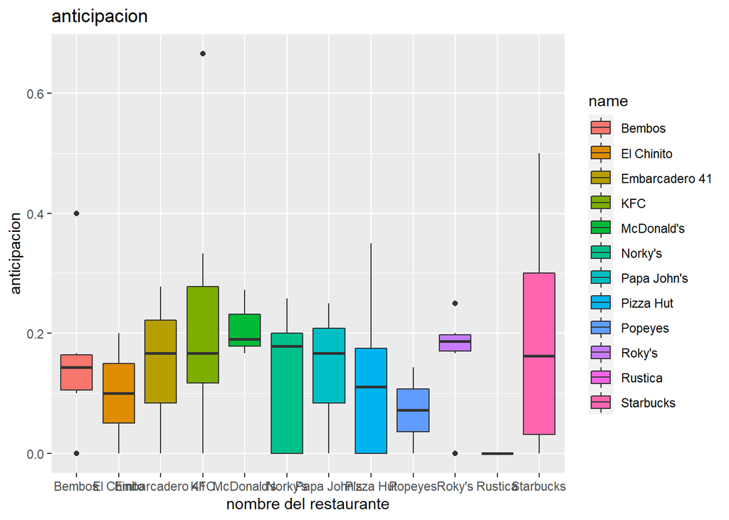

```r
(data8 <- data5 %>%
    group_by(name,anticipacion ) %>%
    ggplot(mapping = aes(x = name, y = anticipacion, fill = name))+
    geom_boxplot()+
    labs (title = "anticipacion",
          x = "nombre del restaurante",
          y = "anticipacion"
    ))
```

**analisis de la variable disgusto**

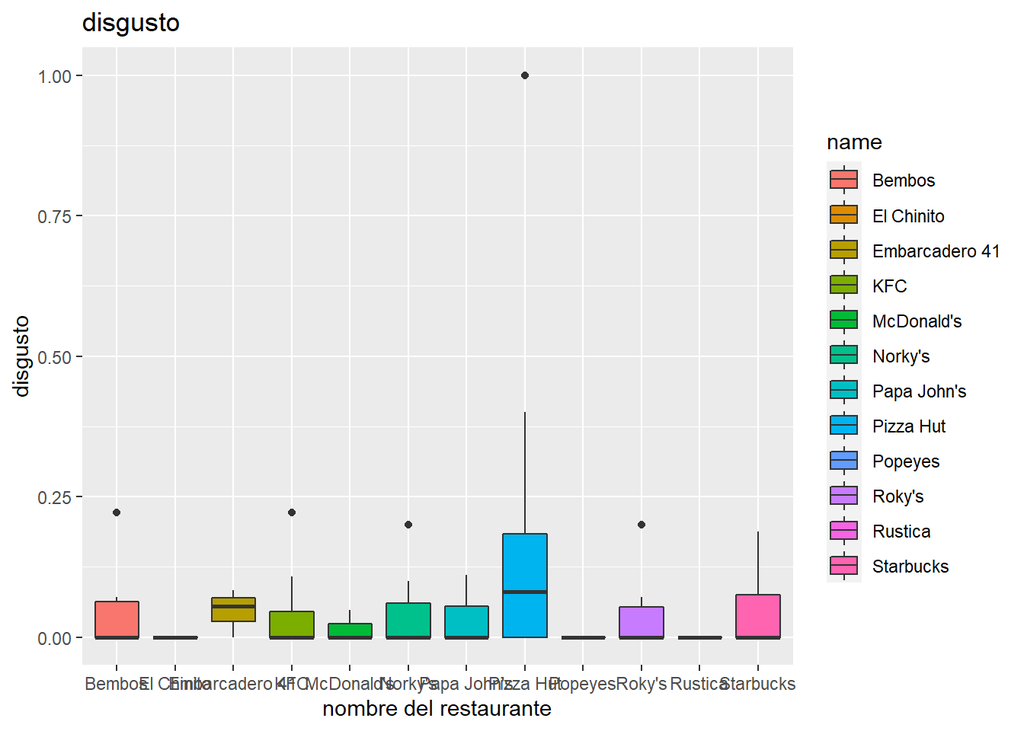

```r
(data9 <- data5 %>%
    group_by(name,disgusto ) %>%
    ggplot(mapping = aes(x = name, y = disgusto , fill = name))+
    geom_boxplot()+
    labs (title = "disgusto",
          x = "nombre del restaurante",
          y = "disgusto"
    ))
```

**analisis de la variable temor**

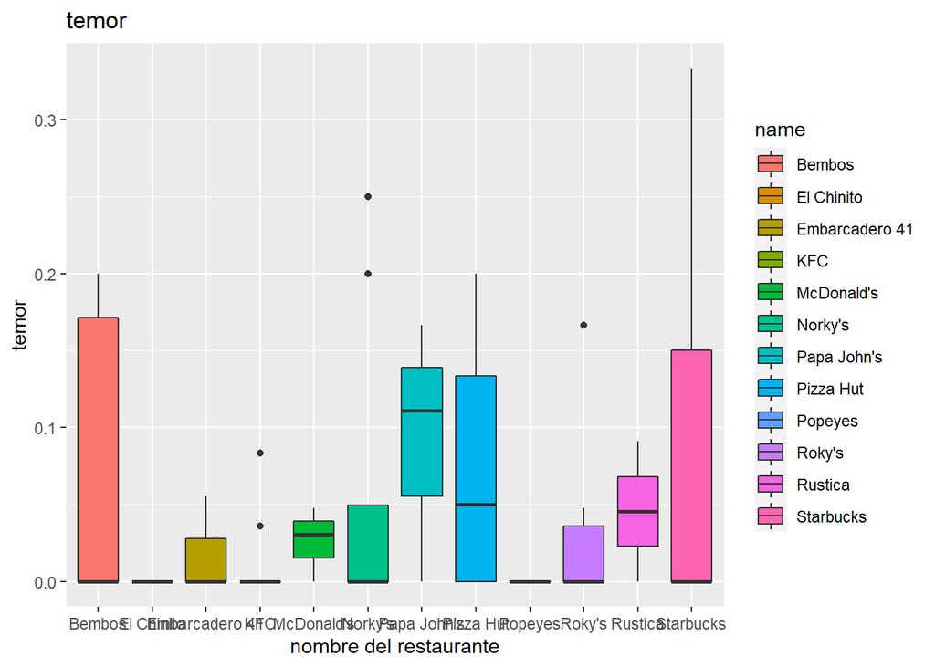

```r
(data10 <- data5 %>%
    group_by(name,temor ) %>%
    ggplot(mapping = aes(x = name, y = temor , fill = name))+
    geom_boxplot()+
    labs (title = "temor",
          x = "nombre del restaurante",
          y = "temor"
    ))
```

**analisis de la variable alegria**

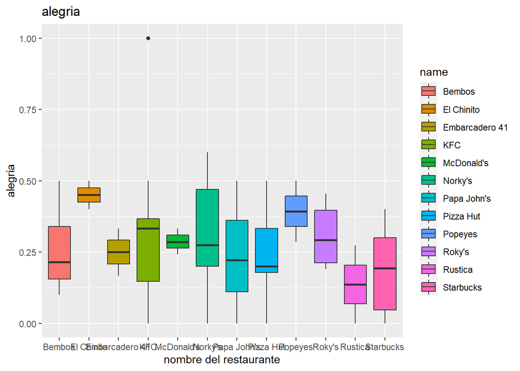

```r
(data11 <- data5 %>%
    group_by(name,alegria ) %>%
    ggplot(mapping = aes(x = name, y = alegria , fill = name))+
    geom_boxplot()+
    labs (title = "alegria",
          x = "nombre del restaurante",
          y = "alegria"
    ))
```

**analisis de la variable tristesa**

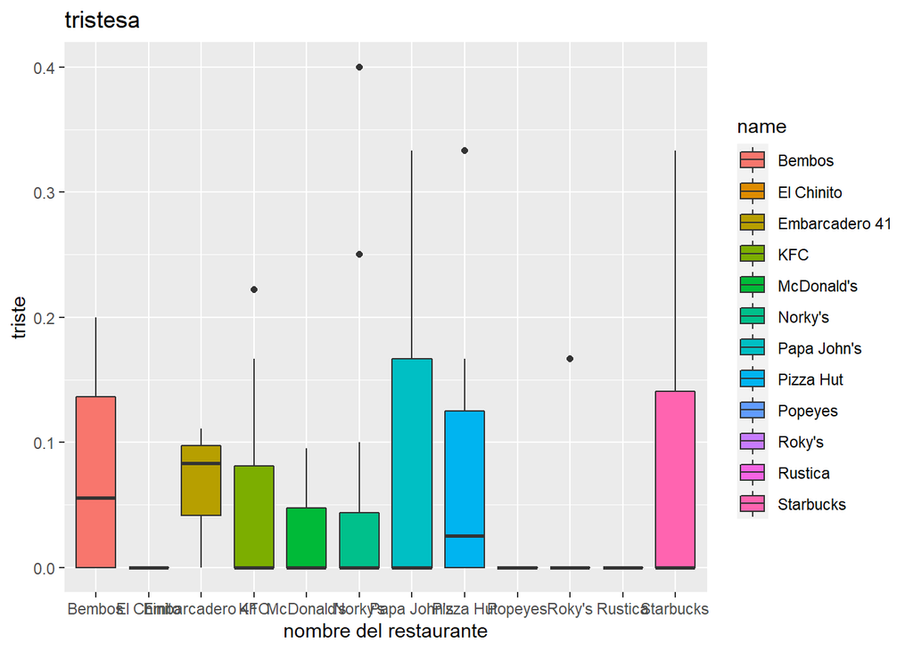

```r
(data12 <- data5 %>%
    group_by(name,tristesa ) %>%
    ggplot(mapping = aes(x = name, y = tristesa , fill = name))+
    geom_boxplot()+
    labs (title = "tristesa",
          x = "nombre del restaurante",
          y = "triste"
    ))
```

**analisis de la variable sorpresa**

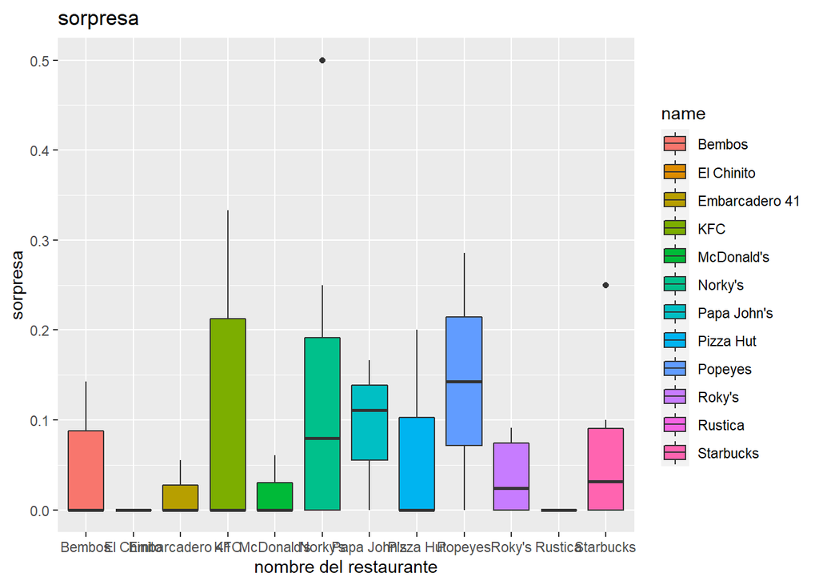

```r
(data13 <- data5 %>%
    group_by(name,sorpresa ) %>%
    ggplot(mapping = aes(x = name, y = sorpresa , fill = name))+
    geom_boxplot()+
    labs (title = "sorpresa",
          x = "nombre del restaurante",
          y = "sorpresa"
    ))
```

**analisis de la variable negative**

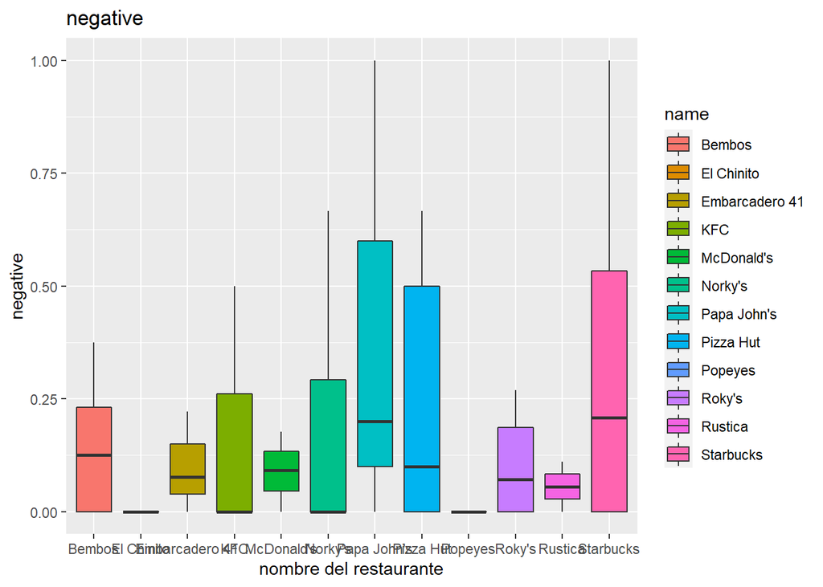

```r
(data14 <- data5 %>%
    group_by(name,negative ) %>%
    ggplot(mapping = aes(x = name, y = negative , fill = name))+
    geom_boxplot()+
    labs (title = "negative",
          x = "nombre del restaurante",
          y = "negative"
    ))
```

**analisis de la variable positive**

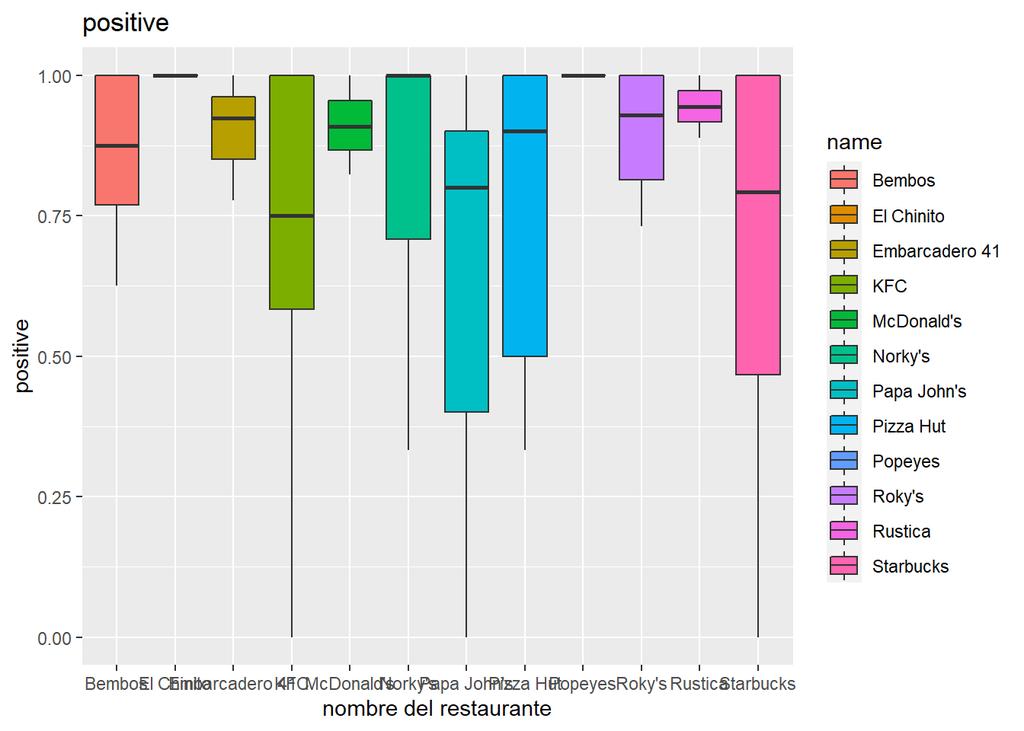

```r
(data15 <- data5 %>%
    group_by(name,positive ) %>%
    ggplot(mapping = aes(x = name, y = positive , fill = name))+
    geom_boxplot()+
    labs (title = "positive",
          x = "nombre del restaurante",
          y = "positive"
    ))
```

**analisis de la variable stars_1**

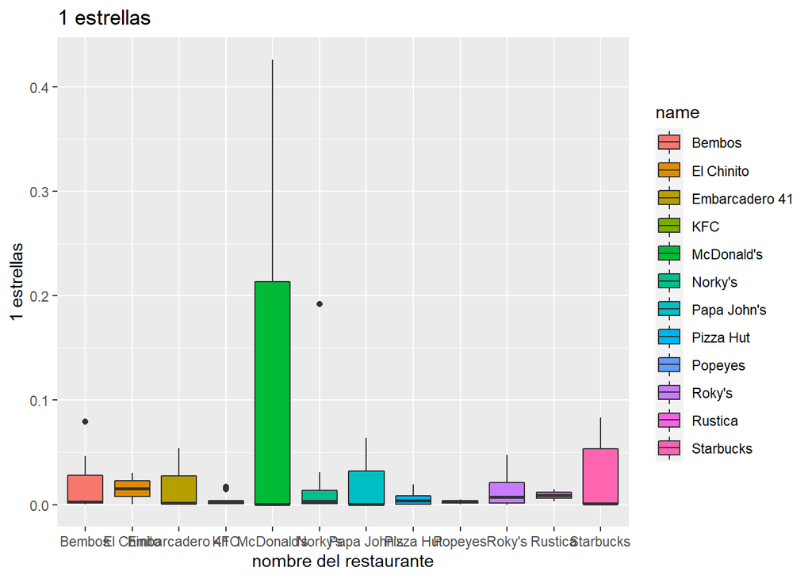

```r
(data16 <- data5 %>%
    group_by(name,stars_1 ) %>%
    ggplot(mapping = aes(x = name, y = stars_1, fill = name))+
    geom_boxplot()+
    labs (title = "1 estrellas",
          x = "nombre del restaurante",
          y = "1 estrellas"
    ))
```

**analisis de la variable stars_2**

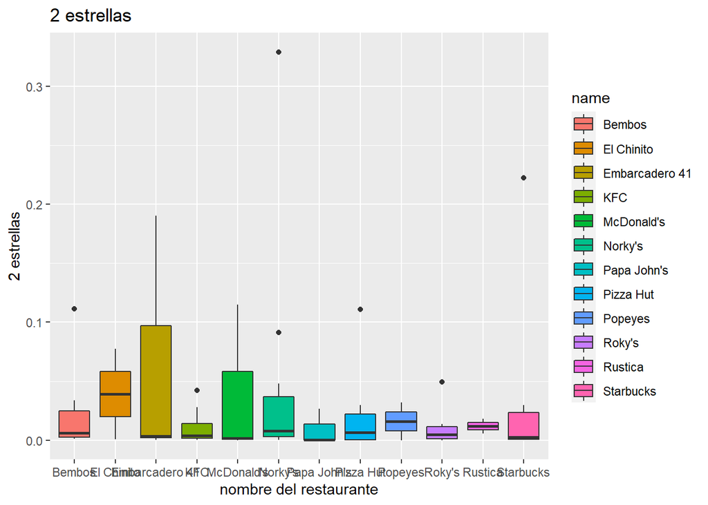

```r
(data17 <- data5 %>%
    group_by(name,stars_2 ) %>%
    ggplot(mapping = aes(x = name, y = stars_2, fill = name))+
    geom_boxplot()+
    labs (title = "2 estrellas",
          x = "nombre del restaurante",
          y = "2 estrellas"
    ))
```

**analisis de la variable stars_3**

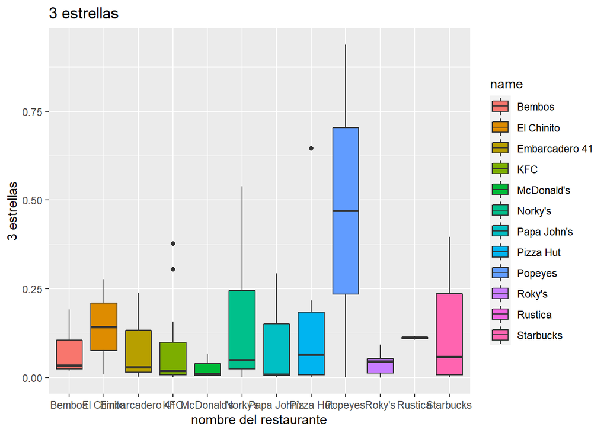

```r
(data18 <- data5 %>%
    group_by(name,stars_3 ) %>%
    ggplot(mapping = aes(x = name, y = stars_3, fill = name))+
    geom_boxplot()+
    labs (title = "3 estrellas",
          x = "nombre del restaurante",
          y = "3 estrellas"
    ))
```

**analisis de la variable stars_4**

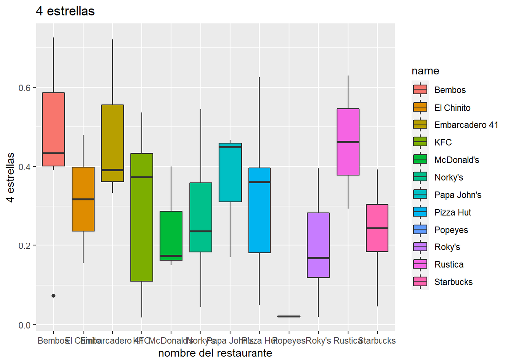

```r
(data19 <- data5 %>%
    group_by(name,stars_4 ) %>%
    ggplot(mapping = aes(x = name, y = stars_4, fill = name))+
    geom_boxplot()+
    labs (title = "4 estrellas",
          x = "nombre del restaurante",
          y = "4 estrellas"
    ))
```

**analisis de la variable stars_5**

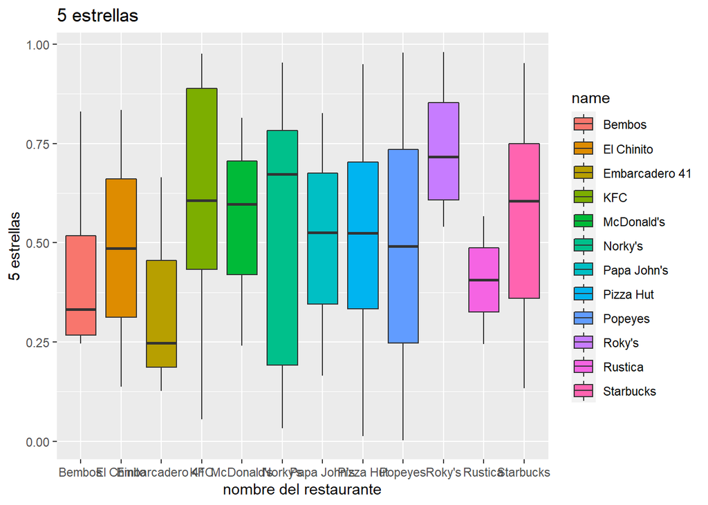

```r
(data20 <- data5 %>%
    group_by(name,stars_5 ) %>%
    ggplot(mapping = aes(x = name, y = stars_5, fill = name))+
    geom_boxplot()+
    labs (title = "5 estrellas",
          x = "nombre del restaurante",
          y = "5 estrellas"
    ))
```

# Distribucion de variables

**histograma de stars_1**

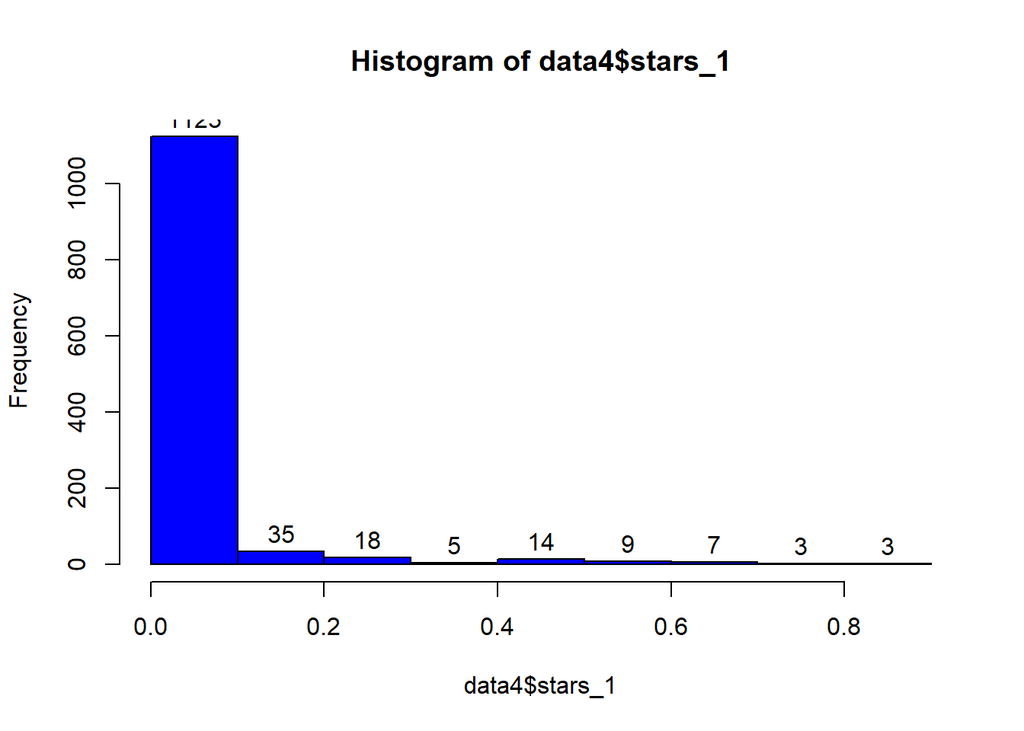

```r
hist(data4$stars_1, freq = T, col = "blue", labels = T)
```

**histograma de stars_2**

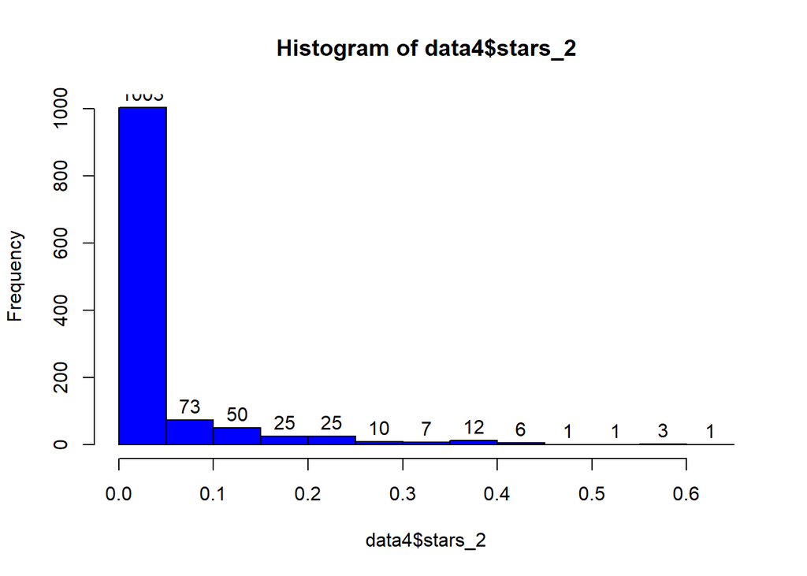

```r
hist(data4$stars_2, freq = T, col = "blue", labels = T)
```

**histograma de stars_3**

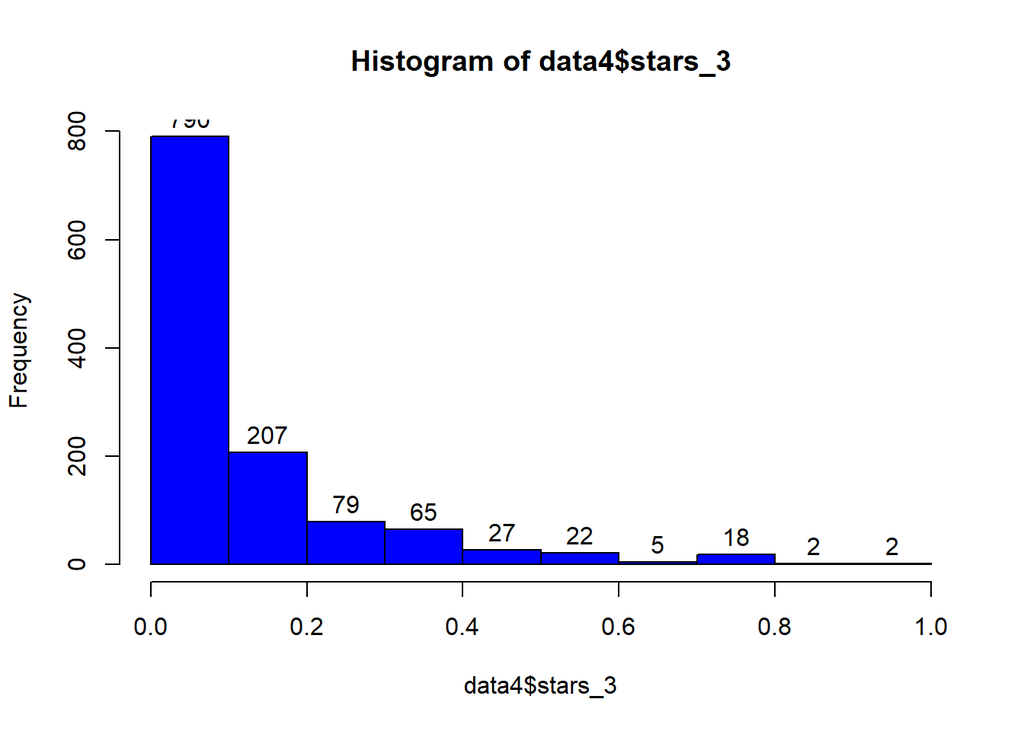

```r
hist(data4$stars_3, freq = T, col = "blue", labels = T)
```

**histograma de stars_4**

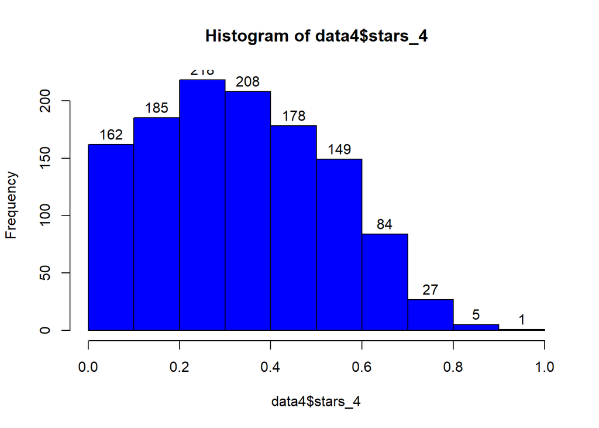

```r
hist(data4$stars_4, freq = T, col = "blue", labels = T)
```

**histograma de stars_5**

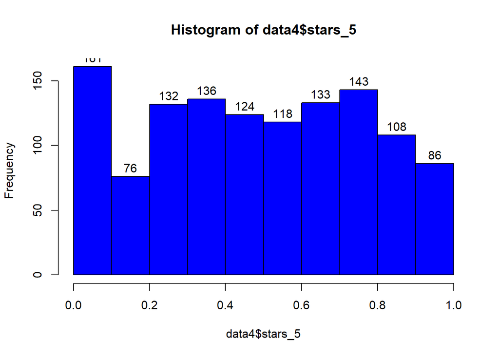

```r
hist(data4$stars_5, freq = T, col = "blue", labels = T)
```

**histograma de positive**

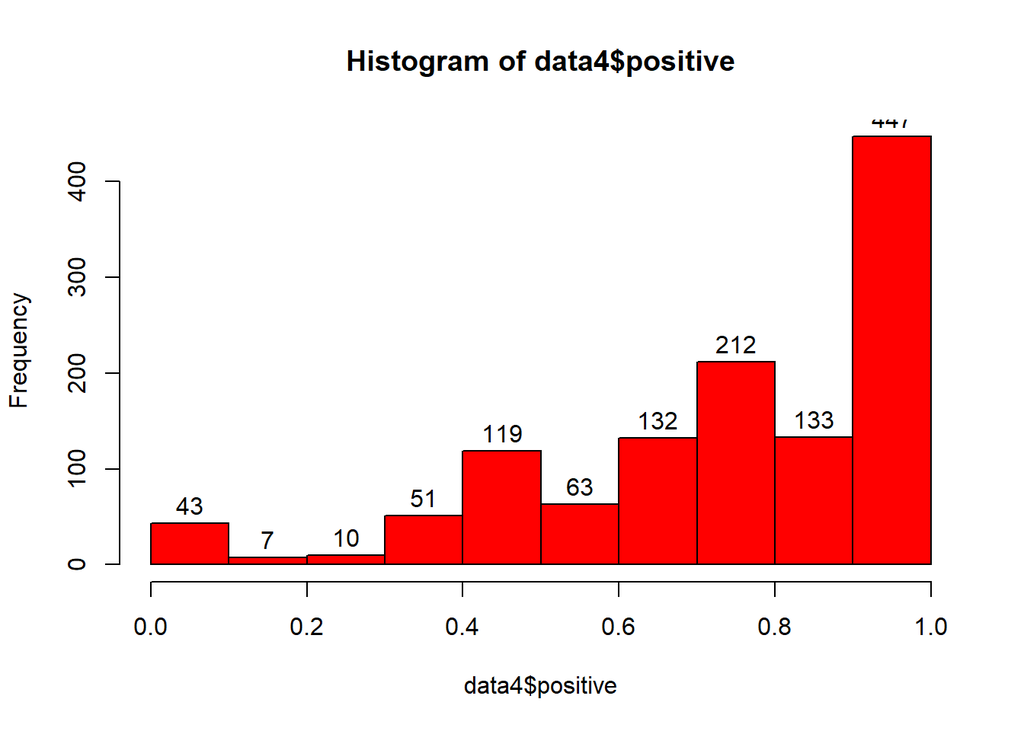

```r
hist(data4$positive, freq = T, col = "red", labels = T)
```

**histograma de negative**

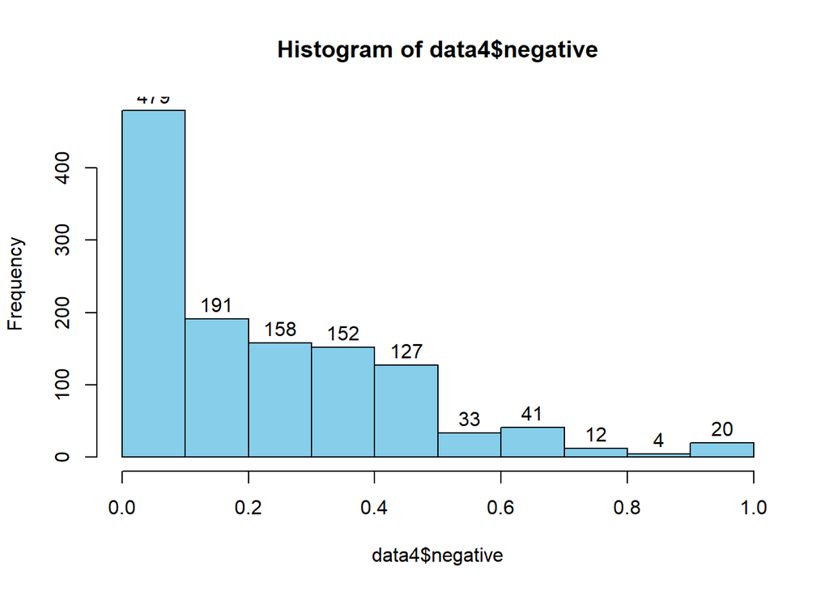

```r
hist(data4$negative, freq = T, col = "skyblue", labels = T)
```

**histograma de sopresa**

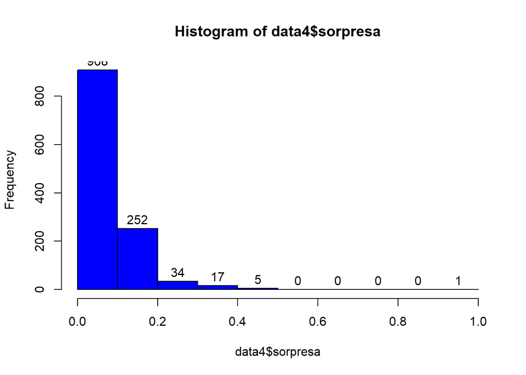

```r
hist(data4$sorpresa, freq = T, col = "blue", labels = T)
```

**histograma de tristesa**

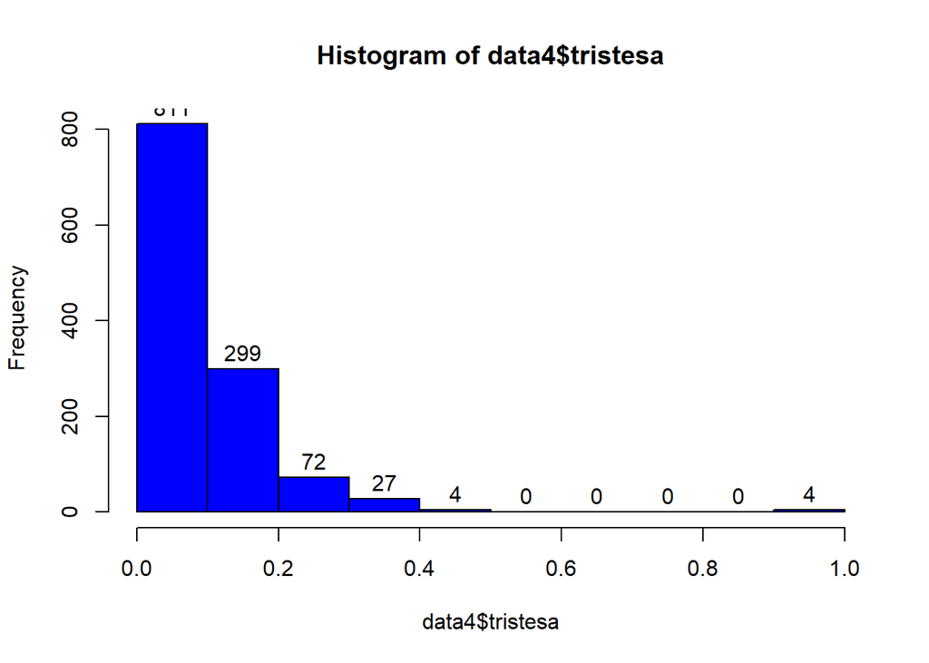

```r
hist(data4$tristesa, freq = T, col = "blue", labels = T)
```

**histograma de alegria**

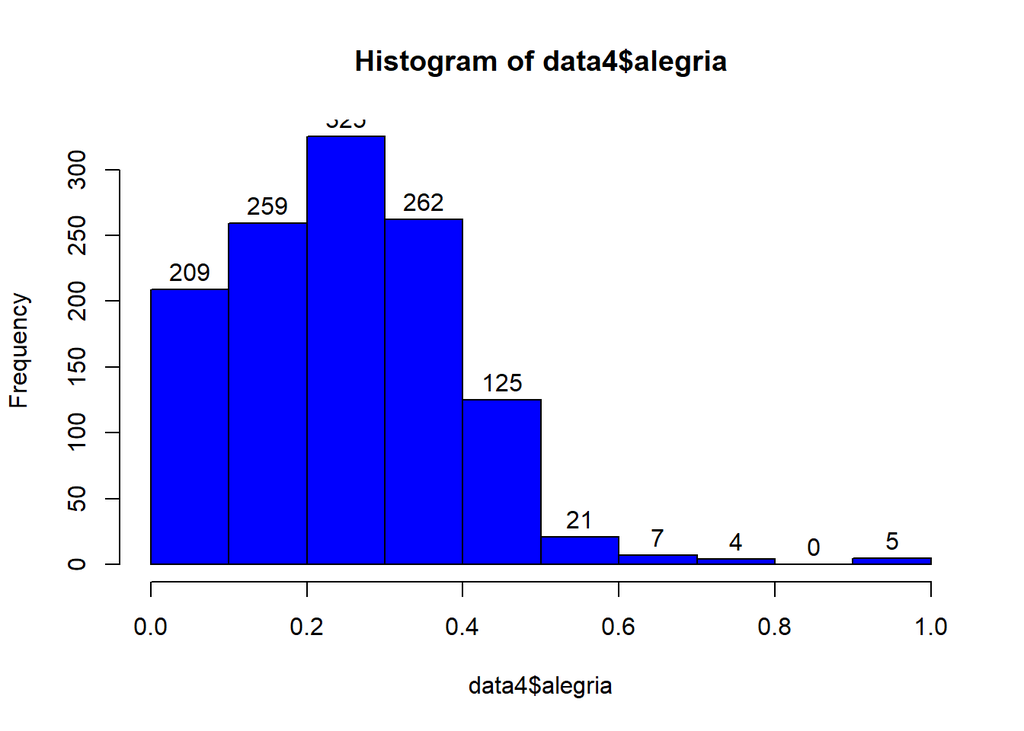

```r
hist(data4$alegria, freq = T, col = "blue", labels = T)
```

**histograma de temor**